### Introduction

In the United States, one of the systems where racism is very prominent is its prision system. Due to the history of some unjust incarceration polices, the proportion of white people and people of color that are incarcerated is very disproportionate.

The dataset we will be using is collected by Vera Institute, which contains the county and jurisdiction level jail data from 1970 to 2018, prison data from 1983 to 2016, and State level prison data from 2019 to 2021.

### Variables

Some of the variables we will be focusing on:  
First we will include the variables for location and time (year, state, county_name) for the location of the jail data to evaluate how each county is doing.

Because of the disproportion of white people and people of color that are incarcerated, we will be analyzing the incarcerated population by race (‘aapi_prison_pop, black_prison_pop, latinx_prison_pop, native_prison_pop, other_race_prison_pop, white_prison_pop’) These variables refer to the prison population on December 31 of a given year in different race categories, Asian or Pacific Islander, Black, Latinx, Native American, White, or Other.

We will also be looking at the percent incarcerated from ages 15 to 64 of different races. ( aapi_prison_pop_rate, black_prison_pop_rate, latinx_prison_pop_rate, native_prison_pop_rate, white_prison_pop_rate) The incarceration rate refers to the number of people incarcerated compared to people of that race living there.

### Summary information

In order to show the disproportion of races, the data is summarized by 5 values, the average number of incarcerated people across different races, the highest number of incarcerated people across different races, prison population change from 1970 and 2018 across different races, the average rate of incarcerated people, the highest rate of incarcerated people across different races.

1. What is the average number of incarcerated people across different races?

```
##   White Population Black Population Latinx Population
## 1         162.7287          247.166          101.4304
##   Asian or Pacific Islander Population Native American Population
## 1                             7.345527                    7.29707
##   Other Race Population
## 1              9.885212
```

- First, we want to see what the average prison population is for different races. This stat can be used to summarize the average difference in races. The average population of incarcerated people across different races is 163 in white population, 247 in black population, 101 in latinx population, 7 in asian or pacific islander population, 7 native american population, and 9 in other race population.
2. What is the highest prison population of incarcerated people across different races?

```
##   White Population Black Population Latinx Population
## 1             9945            24818             25074
##   Asian or Pacific Islander Population Native American Population
## 1                                 2031                       1148
##   Other Race Population
## 1                  4285
```

- Second, we are going to find the highest number of prisoners at a time across different races. The maximum population of incarcerated people across different races is 9945 in white population, 24818 in black population, 25074 in latinx population, 2031 in asian or pacific islander population, 1148 native american population, and 4285 in other race population.
3. What is the prison population change from 1970 and 2018 between white people and black people?

```
##   White Population Black Population
## 1             1666             3171
```

```
##   White Population Prison Rate Black Population Prison Rate
## 1                     437.4771                     2785.146
##   Latinx Population Prison Rate
## 1                      776.1622
##   Asian or Pacific Islander Population Prison Rate
## 1                                         34.71696
##   Native American Population Prison Rate
## 1                               640.1614
```

- We want to calculate the prison rate as compared to the population in the location they are residing in to get a more accurate picture. The average rate of incarcerated people across different races is 437.4771 in white population, 2785.146 in black population, 776.1622 in latinx population, 34.71696 in asian or pacific islander population, and 640.1614 native american population.
5. What is the highest rate of incarcerated people across different races?

```
##   White Population Prison Rate Black Population Prison Rate
## 1                     29870.13                      2107143
##   Latinx Population Prison Rate
## 1                       1200000
##   Asian or Pacific Islander Population Prison Rate
## 1                                          5882.35
##   Native American Population Prison Rate
## 1                                  6e+05
```

- We want to calculate the prison rate as compared to the population in the location they are residing in to get a more accurate picture. The highest rate of incarcerated people across different races is 29870.13 in white population, 2107143 in black population, 1200000 in latinx population, 5882.35 in asian or pacific islander population, and 600000 native american population.

### Visualization Charts

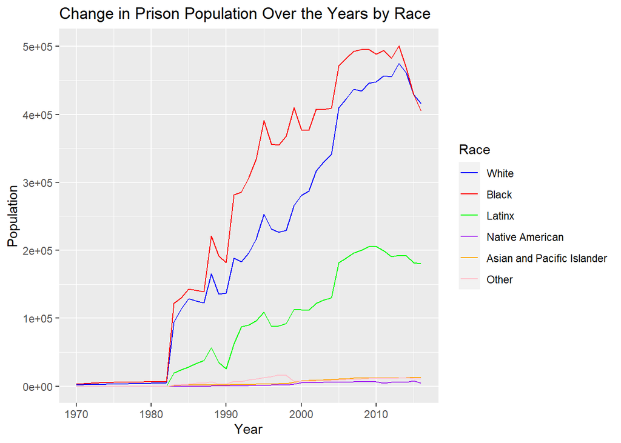

This graph shows the Population change in prisons on a yearly basis. It is set to visualize the differences in incarceration in the United States. From the graph we can see that the race with the most incarcerated people has been black people. The number of people in prison has an overall upward trend, but has been decreasing in recent years.

### Map

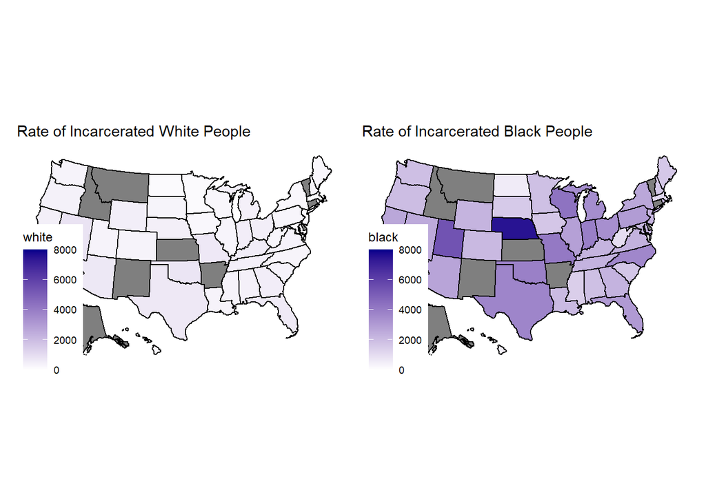

This map compares the rates of incarceration of white people and black people in different states. Since the rates of the other races are missing more data than these two races. The map shows how highly racist the prison system is. Also, the rates of Nebraska, US has the most inequality in incarceration rates between the two races.

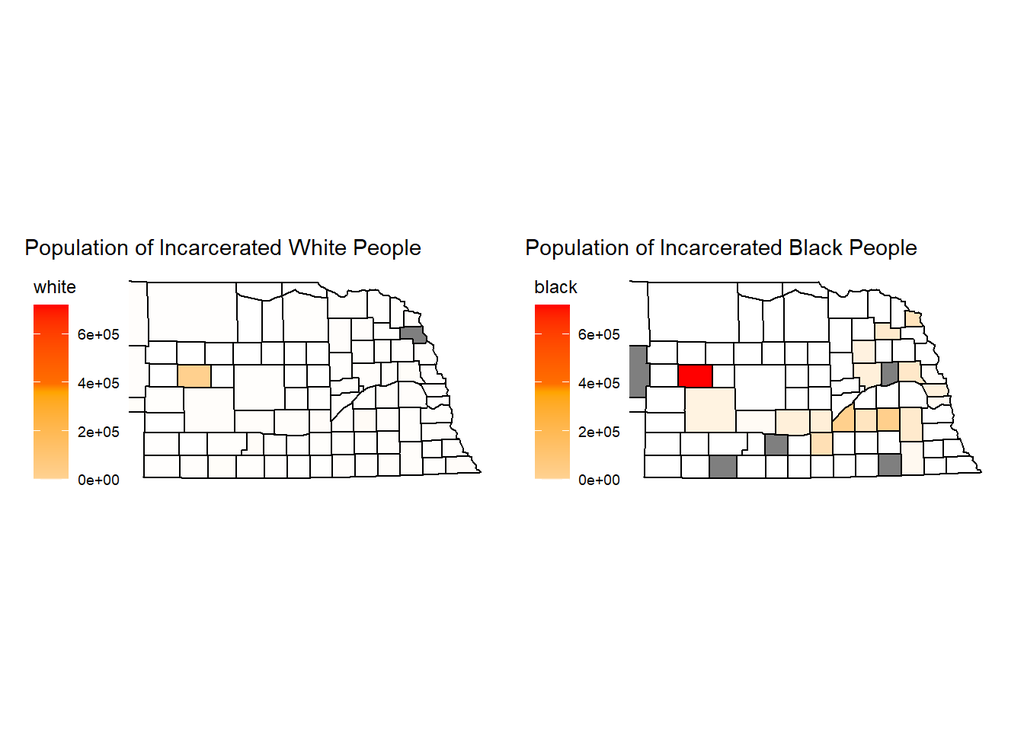